# Using TF-Gene Target network to perform clustering analysis

Weixu Wang

### Preprocessing the dataset

Before running ICAnetTF, we first need to preprocess the dataset, here I used the preprocessing guidline provided by SCENIC[1]

```r
setwd("/mnt/data2/wangweixu/mouseData")
source("ICAnet_functions.R")
library(Seurat)
library(cowplot)
mouseData <- read.table("/mnt/data4/weixu/MCTA/immuneAtlas/Mouse/GSE60361_C1-3005-Expression.txt",header=TRUE,row.names=1)
cellid <- read.csv("/mnt/data4/weixu/MCTA/immuneAtlas/Mouse/cellid.csv",header=TRUE)

mouseData <- as.matrix(mouseData)
mouseData <- mouseData[rowSums(mouseData)>90,]
##filtering the mouse dataset

mouseData <- CreateSeuratObject(counts = mouseData, project = "mouse.brain", min.cells = 0.01*ncol(mouseData))
mouseData$celltype <- cellid[,3]
mouseData$batch <- rep("mouseData",ncol(mouseData))
mouseData <- NormalizeData(mouseData, normalization.method = "LogNormalize", scale.factor = 10000)
```

### Setup the Motif-Gene network

For this tutorial, I will introduce how to incorporate TF-Gene target network to analyze the mouse brain dataset sequenced by Zeisel et al. There are 3005 single cells that were sequenced on the Illumina HiSeq 2000. The raw data can be found on GEO:GSE60361 Different with SCENIC[1], ICAnet was first create a Motif-Gene network, then performing target enrichment analysis for each Motif on each ICA-components. Meanwhile, it also consider whether each motif-associated transcriptional factor is also ‘activated’. First, ICAnet could create Motif-Gene network based on Motif-gene association matrix provided by RcisTarget[2].

```r
library(RcisTarget)
Motif_Net <- TF_Net_Generate("/mnt/data2/wangweixu/mm9-500bp-upstream-10species.mc8nr.feather",cutoff=1)
```

```
## Loading TF,motif annotation dataset...
## Trimming the interaction...
## Generating TF-Gene-Net...
## Done
```

**Important parameters are as follows**: * *cutoff*: this parameters is to select the appropriate target for each TF through perform Z-score transformation on column or row of the matrix, and only preserved those interactions which their transformed value > cutoff. Therefore, an appropriate cutoff needs to be selected carefully. the defualt value is 1

### Running ICAnetTF using motif-gene network as input

Then, we run ICAnetTF to decompose gene expression matrix into a number of independent components. After running ICAnetTF, the Seurat obj will be assighed a assay “IcaNet_TF”, which save TF-regulons activity matrix

```r
Ica.mouse <- ICAcomputing(mouseData,ICA.type="JADE",RMT=TRUE,two.stage=FALSE)
```

```
## [1] "batch 1 Indepdent Component Analysis"
## [1] "emmm...centering..."
```

```
## Centering data matrix
```

```
## [1] "Done Centering"
## [1] "Using RMT to estimate number of module"
```

```
## [1] "RMT estimate 32 expression programm"
```

```r
mouseData  <- RunICAnetTF(mouseData,Ica.mouse$ica.pooling,species = 10090,W.top.TFs=3,W.top.genes=2.5,aucMaxRank=600,Motif_Net=Motif_Net,TF_motif_annot=motifAnnotations_mgi_v8)
```

```
## Running on TF-Gene Network
## Running on the 1st component
## Identify 13 activated TF
## perform modularity test[1] "Starting Monte Carlo Runs"
##
## Running on the 2st component
## Identify 6 activated TF
## perform modularity test[1] "Starting Monte Carlo Runs"
##
## Running on the 3st component
## Identify 7 activated TF
## perform modularity test[1] "Starting Monte Carlo Runs"
##
## Running on the 4st component
## Identify 10 activated TF
## perform modularity test[1] "Starting Monte Carlo Runs"
##
## Running on the 5st component
## Identify 12 activated TF
## perform modularity test[1] "Starting Monte Carlo Runs"
##
## Running on the 6st component
## Identify 15 activated TF
## perform modularity test[1] "Starting Monte Carlo Runs"
##
## Running on the 7st component
## Identify 12 activated TF
## perform modularity test[1] "Starting Monte Carlo Runs"
##
## Running on the 8st component
## Identify 12 activated TF
## perform modularity test[1] "Starting Monte Carlo Runs"
##
## Running on the 9st component
## Identify 12 activated TF
## perform modularity test[1] "Starting Monte Carlo Runs"
##
## Running on the 10st component
## Identify 19 activated TF
## perform modularity test[1] "Starting Monte Carlo Runs"
```

[output cut: 74 more lines]

```
## Identify 8 activated TF
## perform modularity test[1] "Starting Monte Carlo Runs"
##
## Running on the 30st component
## Identify 16 activated TF
## perform modularity test[1] "Starting Monte Carlo Runs"
##
## Running on the 31st component
## Identify 18 activated TF
## perform modularity test[1] "Starting Monte Carlo Runs"
##
## Running on the 32st component
## Identify 2 activated TF
## perform modularity test[1] "Starting Monte Carlo Runs"
## [1] "num:698"
```

```
## Quantiles for the number of genes detected by cell:
## (Non-detected genes are shuffled at the end of the ranking. Keep it in mind when choosing the threshold for calculating the AUC).
```

```
##     min      1%      5%     10%     50%    100%
##  748.00 1031.32 1410.40 1726.00 3605.00 8059.00
```

```
## Using 6 cores.
```

```
## Using 6 cores.
```

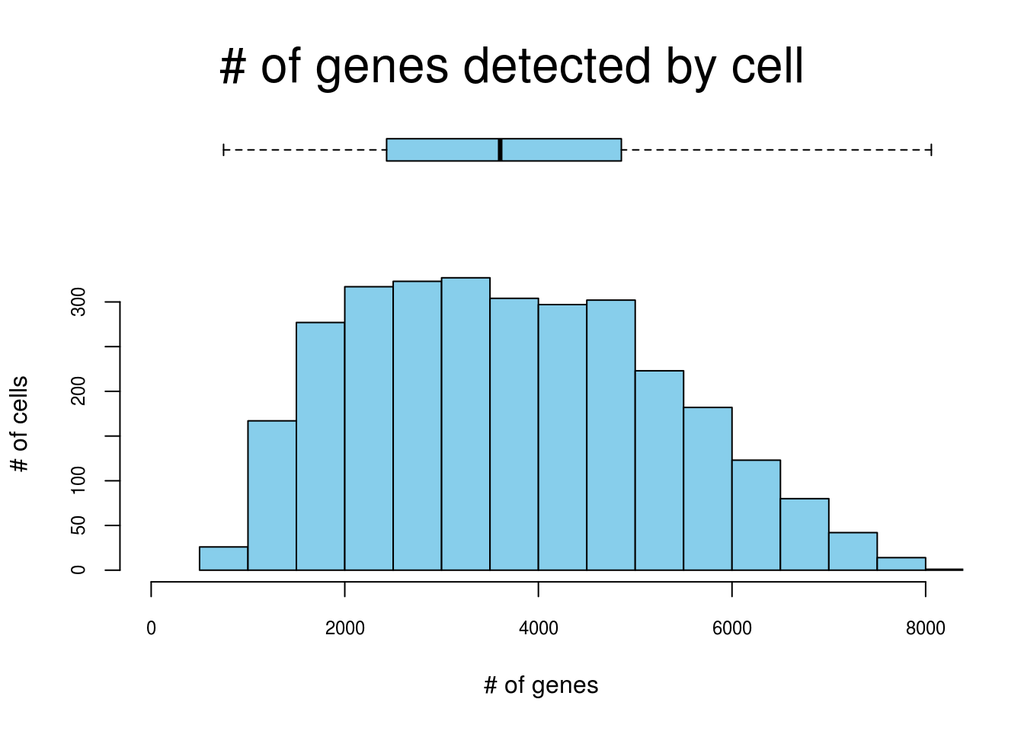

**Important parameters are as follows**: * *W.top.TFs* the weight threshold to define “activated” TFs which their attributes values were used to compare the similarity between different ICs. * *W.top.genes* the weight threshold to define “activated” Genes which their attributes values were used to compare the similarity between different ICs. * *TF_motif_annot* The TF-binding motif matrix, which provided by RcisTarget[1] * *cutoff* interger value to determine the significant TF-regulons, default value cutoff=0.01

Meanwhile ICAntTF also return the details of module informations includes each module’s TF activity value and their statistical significance. We could check the module information through following commends.

```r
moduleInfor <- mouseData@misc$IcaNet_geneSets_TF_moduleInfor
head(moduleInfor)
```

```
##                                                 gene      moduleSize
## ICAnet-1-4-Bcl11a+hocomoco__BC11A_HUMAN.H10MO.C "Bcl11a"  "4"
## ICAnet-1-3-Foxp1+cisbp__M0721                   "Foxp1"   "3"
## ICAnet-1-3-Foxp1+cisbp__M0727                   "Foxp1"   "3"
## ICAnet-1-3-Foxp1+cisbp__M0748                   "Foxp1"   "3"
## ICAnet-1-50-Foxp1+cisbp__M0755                  "Foxp1"   "50"
## ICAnet-1-7-Neurod2+hocomoco__NDF2_HUMAN.H10MO.D "Neurod2" "7"
##                                                 TF_list
## ICAnet-1-4-Bcl11a+hocomoco__BC11A_HUMAN.H10MO.C "1810024B03Rik"
## ICAnet-1-3-Foxp1+cisbp__M0721                   "2210418O10Rik"
## ICAnet-1-3-Foxp1+cisbp__M0727                   "2310011J03Rik"
## ICAnet-1-3-Foxp1+cisbp__M0748                   "2610008E11Rik"
## ICAnet-1-50-Foxp1+cisbp__M0755                  "2810403A07Rik"
## ICAnet-1-7-Neurod2+hocomoco__NDF2_HUMAN.H10MO.D "4921501E09Rik"
##                                                 modularity
## ICAnet-1-4-Bcl11a+hocomoco__BC11A_HUMAN.H10MO.C "-0.104492175183937"
## ICAnet-1-3-Foxp1+cisbp__M0721                   "-0.105103253837964"
## ICAnet-1-3-Foxp1+cisbp__M0727                   "-0.108083841105661"
## ICAnet-1-3-Foxp1+cisbp__M0748                   "-0.108220231624089"
## ICAnet-1-50-Foxp1+cisbp__M0755                  "0.055179371430194"
## ICAnet-1-7-Neurod2+hocomoco__NDF2_HUMAN.H10MO.D "-0.0795603423431019"
##                                                 significance TF_activity_all
## ICAnet-1-4-Bcl11a+hocomoco__BC11A_HUMAN.H10MO.C "0"          "3.75981675707898"
## ICAnet-1-3-Foxp1+cisbp__M0721                   "0.01"       "4.3601223827535"
## ICAnet-1-3-Foxp1+cisbp__M0727                   "0"          "4.3601223827535"
## ICAnet-1-3-Foxp1+cisbp__M0748                   "0"          "4.3601223827535"
## ICAnet-1-50-Foxp1+cisbp__M0755                  "0.01"       "4.3601223827535"
## ICAnet-1-7-Neurod2+hocomoco__NDF2_HUMAN.H10MO.D "0.01"       "4.98304980043561"
```

### Using TF-regulon predict by ICAnetTF to perform cell clustering

As ICAnet is scaning the enrichments of all possible TF-motif regulation targets. It tends to detect much more possible TF-regulons. We used these modules to perform cell clustering.

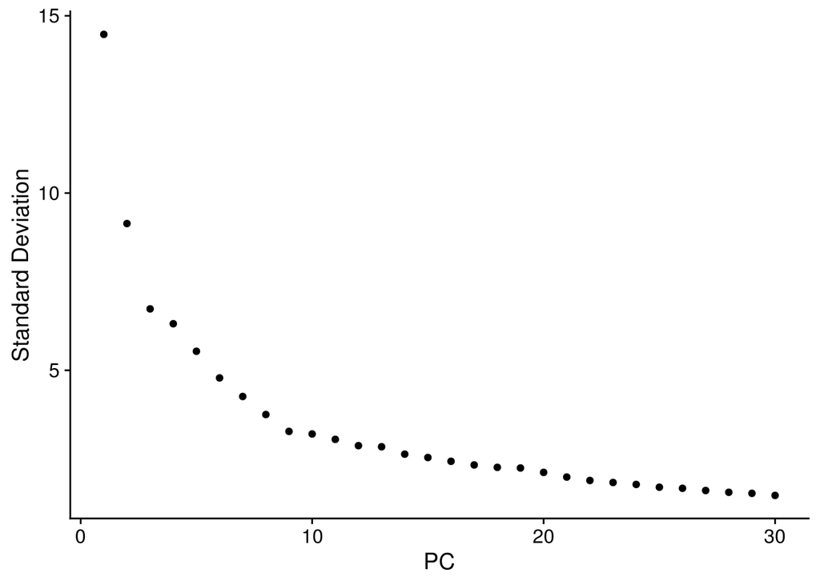

```r
mouseData <- RunPCA(mouseData,npcs = 30,features=rownames(mouseData),verbose = F)
ElbowPlot(mouseData,ndims=30)
```

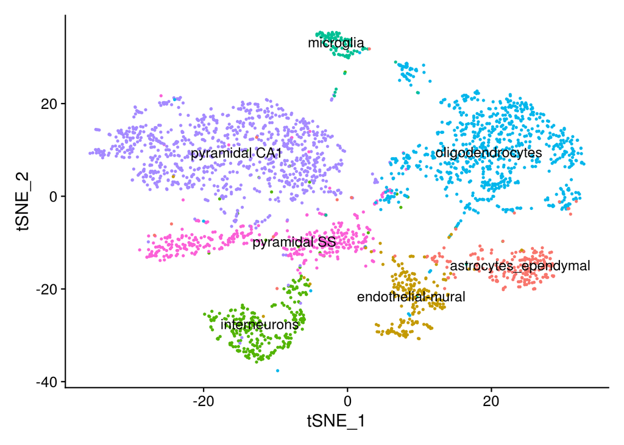

```r
mouseData <- RunTSNE(mouseData, reduction = "pca", dims = 1:20, reduction.name = "tsne",  reduction.key = "tSNE_")
DimPlot(mouseData, reduction = 'tsne',  group.by = 'celltype',label=1)+NoLegend()
```

We could notice that the cells are largely grouped according to cell identity. To show its clustering performance, I run louvian clustering algorithm to cluster the cells to show its performance

```r
library(mclust)
mouseData <- FindNeighbors(mouseData, dims = 1:20,reduction="pca")
mouseData <- FindClusters(mouseData, resolution = 0.2,algorithm=2)
```

```
## Modularity Optimizer version 1.3.0 by Ludo Waltman and Nees Jan van Eck
##
## Number of nodes: 3005
## Number of edges: 107036
##
## Running Louvain algorithm with multilevel refinement...
## Maximum modularity in 10 random starts: 0.9405
## Number of communities: 7
## Elapsed time: 0 seconds
```

```r
adjustedRandIndex(as.numeric(as.factor(mouseData$celltype)),as.numeric(mouseData@active.ident))
```

```
## [1] 0.8815062
```

We could found that ICAnetTF could reach highly accurate clustering performance (ARI>0.85), which is very comparable and even surpass the clustering performance of SCENIC[1] and SC3[2]. Notebly, compare with SCENIC, ICAnet identify activated TF-regulon within 10 minutes.

### Reference

[1] Aibar S, González-Blas C B, Moerman T, et al. SCENIC: single-cell regulatory network inference and clustering[J]. Nature methods, 2017, 14(11): 1083-1086. [2] Kiselev V Y, Kirschner K, Schaub M T, et al. SC3: consensus clustering of single-cell RNA-seq data[J]. Nature methods, 2017, 14(5): 483-486.